# Theta and DE

Thomas Quinn

March 20, 2017

Here, I explore how differential proportionality (disjointed, $\theta$) relates to differential expression (DE). For this, I use a data set simulated with the R package `polyester`, aligned with Salmon, and mapped with quasi-counts.

Let us import the data and take a random sample of 10,000 genes:

```r
# Import simulated transcriptome and take random sample
txs <- read.csv("/home/thom/Dropbox/R/projects/manuscripts/bench/sim_lv_slQUASI_counts.csv",
                row.names = 1)
rand <- sample(1:nrow(txs), 10000)
txs <- txs[rand, ]
txs[1:5, 1:5]
```

```
##                 sample_01_quant.sf sample_02_quant.sf sample_03_quant.sf
## ENST00000485272            349.252           400.4070           350.9870
## ENST00000526417            222.839           283.5520           216.6970
## ENST00000496596            249.000           265.0000           202.0000
## ENST00000495866            111.095           119.0960            41.1921
## ENST00000602051             83.854            63.1031            75.8605
##                 sample_04_quant.sf sample_05_quant.sf
## ENST00000485272            380.736           450.6270
## ENST00000526417            235.355           225.0480
## ENST00000496596            224.000           215.0000
## ENST00000495866            165.927           189.6910
## ENST00000602051             61.189            51.1313
```

I will remove low counts from the data:

```r
keep <- apply(txs, 1, function(x) sum(x > 20) > 20)
txs <- txs[keep, ]
```

Since this is a simulated data set, we know *a priori* what is differentially expressed. This is available from a separate file:

```r
# Import known annotations
truth <- read.delim("/home/thom/Dropbox/R/projects/manuscripts/bench/lo-var/sim_tx_info.txt", row.names = 1)
rownames(truth) <- unlist(lapply(rownames(truth), function(x) strsplit(x, split = "\\s")[[1]][1]))
true <- truth[rownames(txs), ]
true[1:5, ]
```

```
##                 foldchange.1 foldchange.2 DEstatus.1 DEstatus.2
## ENST00000485272            1            1      FALSE      FALSE
## ENST00000526417            1            1      FALSE      FALSE
## ENST00000496596            1            1      FALSE      FALSE
## ENST00000495866            1            1      FALSE      FALSE
## ENST00000602051            1            1      FALSE      FALSE
```

We will calculate disjointed proportionality on the sample.

```r
library(propriety)
pd.tx <- propd(t(txs), group = c(rep("A", 20), rep("B", 20)))
```

```
## Alert: Replacing 0s in "count matrix" with 1.
```

```
## Alert: Replacing NaN theta values with 1.
```

```
## Alert: 0 counts can distort log-ratio means.
```

Let us define a few functions for DE benchmarking. The first, `calcStats`, calculates precision and recall. The second, `simpleEdger`, runs a basic exact test using the DE software `edgeR`:

```r
calcStats <- function(obs, ref, what){

  all <- rownames(ref)
  tru <- rownames(ref)[ref$DEstatus.1]

  observed <- all %in% obs
  actual <- all %in% tru

  conf <- table(observed, actual)
  if(what == "precision"){
    out <- conf["TRUE", "TRUE"] / (conf["TRUE", "FALSE"] + conf["TRUE", "TRUE"])
  }else if(what == "recall"){
    out <- conf["TRUE", "TRUE"] / (conf["FALSE", "TRUE"] + conf["TRUE", "TRUE"])
  }
  return(out)
}

simpleEdger <- function(ct, group){

  library(edgeR)
  y <- DGEList(counts = ct, group = group)
  y <- calcNormFactors(y)
  y <- estimateCommonDisp(y)
  y <- estimateTagwiseDisp(y)
  et <- exactTest(y)
  tt <- as.data.frame(topTags(et, n = nrow(et)))
  deGenes <- rownames(tt)[tt$FDR < .05]
  plotSmear(et, de.tags = deGenes, cex = 0.5)
  return(deGenes)
}
```

Let us see how well $\theta$ selects for DE transcripts:

```r
metrix <- lapply(c(50, 100, 200, 400, 800, 1600),
                 function(x){

                   check <- shale(pd.tx, cutoff = x, prompt = FALSE)
                   top <- union(check$PartnerName, check$PairName)
                   data.frame(calcStats(top, true, "precision"),
                              calcStats(top, true, "recall"))
                 })
do.call("rbind", metrix)
```

```
##   calcStats.top..true...precision.. calcStats.top..true...recall..
## 1                         0.7714286                    0.009193054
## 2                         0.7068966                    0.013959823
## 3                         0.6551724                    0.019407559
## 4                         0.6258503                    0.031324481
## 5                         0.5751880                    0.052093973
## 6                         0.5439024                    0.075927818
```

Not bad! How does this compare to `edgeR`?

```r
de <- simpleEdger(txs, group = c(rep("A", 20), rep("B", 20)))
```

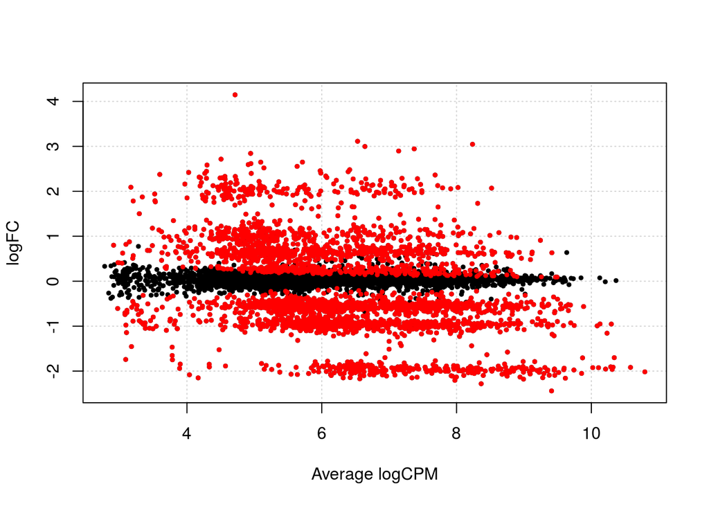

```r
calcStats(de, true, "precision")
```

```
## [1] 0.8727382
```

```r
calcStats(de, true, "recall")
```

```
## [1] 0.9853592
```

Let us view the network to see which nodes (transcripts) get the wrong DE calls:

```
## Visualizing disjointed proportionality (theta_d):
```

```
## Red: Pair has higher LRM in group A than in group B
```

```
## Blue: Pair has lower LRM in group A than in group B
```

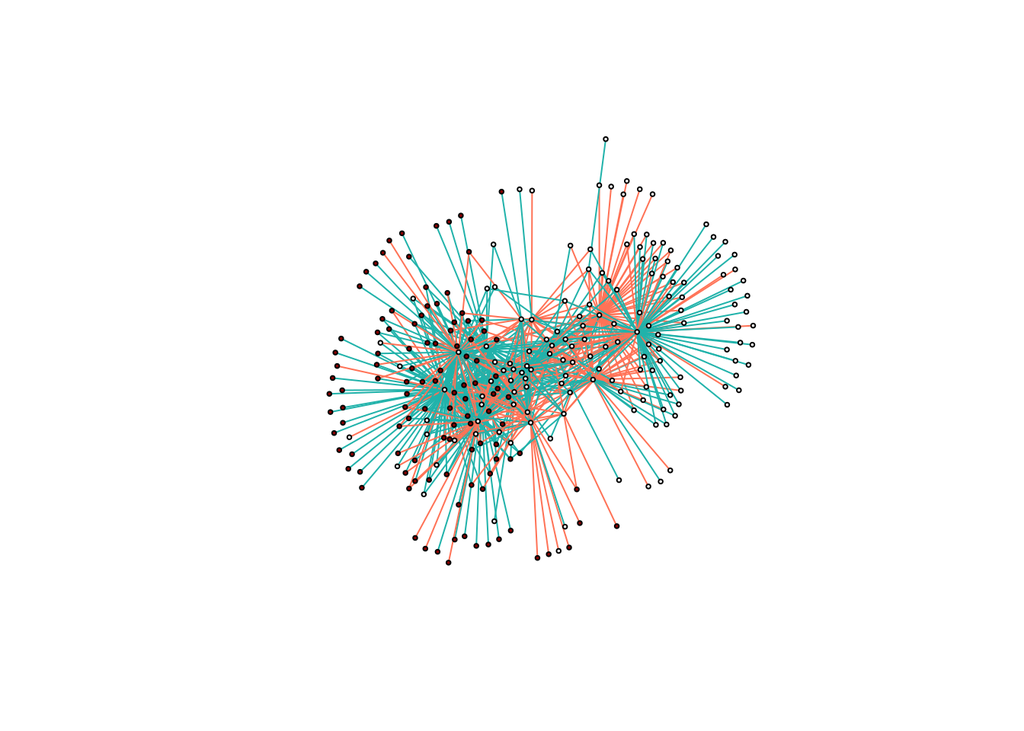

```r
# check <- shale(pd.tx, cutoff = 8000, prompt = FALSE)
# top <- union(check$PartnerName, check$PairName)
# table(true$foldchange.1)
# table(true[top, "foldchange.1"])
g <- plot(pd.tx, cutoff = 800, prompt = FALSE, col1 = rownames(true[true$foldchange.1 == 1,]))
```

Interestingly, most of the wrong DE calls occur in peripheral nodes with low connectivity. In the previous document, we filtered nodes based on connectivity. Here, we will filter edges based on total VLR. Specifically, we remove pairs with a total VLR less than the 25th percentile:

```r
metrix <- lapply(c(50, 100, 200, 400, 800, 1600, 3200, 6400),
                 function(x){

                   check <- shale(pd.tx, cutoff = x, prompt = FALSE)
                   lrv.cutoff <- quantile(check$LRV, probs = .25)
                   check <- check[check$LRV >= lrv.cutoff, ]
                   top <- union(check$PartnerName, check$PairName)
                   data.frame(calcStats(top, true, "precision"),
                              calcStats(top, true, "recall"))
                 })
do.call("rbind", metrix)
```

```
##   calcStats.top..true...precision.. calcStats.top..true...recall..
## 1                         1.0000000                    0.008852571
## 2                         1.0000000                    0.013619339
## 3                         0.9047619                    0.019407559
## 4                         0.8272727                    0.030983997
## 5                         0.7122642                    0.051413006
## 6                         0.6432749                    0.074906367
## 7                         0.6145455                    0.115083418
## 8                         0.5968137                    0.165815458
```

We can compare this to filtering based on the 25th percentile of connectivity:

```r
metrix <- lapply(c(50, 100, 200, 400, 800, 1600, 3200, 6400),
                 function(x){

                   g <- plot(pd.tx, cutoff = x, prompt = FALSE, col1 = rownames(true[true$foldchange.1 == 1,]))
                   d <- sort(igraph::degree(g), decreasing = TRUE)
                   top <- names(d[1:(floor(length(d)*.25))])
                   data.frame(calcStats(top, true, "precision"),
                              calcStats(top, true, "recall"))
                 })
do.call("rbind", metrix)
```

```
##   calcStats.top..true...precision.. calcStats.top..true...recall..
## 1                         1.0000000                    0.002723868
## 2                         1.0000000                    0.004766769
## 3                         0.9047619                    0.006469186
## 4                         0.8055556                    0.009874021
## 5                         0.7121212                    0.016002724
## 6                         0.6764706                    0.023493361
## 7                         0.6447368                    0.033367382
## 8                         0.6063348                    0.045624787
```

```r
metrix <- lapply(c(50, 100, 200, 400, 800, 1600, 3200, 6400),
                 function(x){

                   check <- shale(pd.tx, cutoff = x, prompt = FALSE)
                   lrv.cutoff <- quantile(check$LRV, probs = .5)
                   check <- check[check$LRV >= lrv.cutoff, ]
                   top <- union(check$PartnerName, check$PairName)
                   data.frame(calcStats(top, true, "precision"),
                              calcStats(top, true, "recall"))
                 })
do.call("rbind", metrix)
```

```
##   calcStats.top..true...precision.. calcStats.top..true...recall..
## 1                         1.0000000                    0.006469186
## 2                         1.0000000                    0.010895472
## 3                         1.0000000                    0.016683691
## 4                         1.0000000                    0.029281580
## 5                         1.0000000                    0.049029622
## 6                         0.9905213                    0.071161049
## 7                         0.9908815                    0.110997617
## 8                         0.9915789                    0.160367722
```

```r
metrix <- lapply(c(50, 100, 200, 400, 800, 1600, 3200, 6400),
                 function(x){

                   check <- shale(pd.tx, cutoff = x, prompt = FALSE)
                   lrv.cutoff <- quantile(check$LRV, probs = .75)
                   check <- check[check$LRV >= lrv.cutoff, ]
                   top <- union(check$PartnerName, check$PairName)
                   data.frame(calcStats(top, true, "precision"),
                              calcStats(top, true, "recall"))
                 })
do.call("rbind", metrix)
```

```
##   calcStats.top..true...precision.. calcStats.top..true...recall..
## 1                         1.0000000                    0.004766769
## 2                         1.0000000                    0.008512087
## 3                         1.0000000                    0.012257406
## 4                         1.0000000                    0.018045625
## 5                         1.0000000                    0.029622063
## 6                         1.0000000                    0.042219952
## 7                         0.9893048                    0.062989445
## 8                         0.9930314                    0.097037794
```